# Investigate a Dataset (TMDb Dataset Analysis)

Udacity Data Analyst Nanodegree Project 2

- Introduction
- Data Wrangling
- Exploratory Data Analysis
- RQ1: Does the movie genre affect its score?
- RQ2: Does the movie release year affect its score?
- RQ3: Does the overall vote count affect the score (vote average)?

## Introduction

The purpose of this project is to analyse a dataset and then communicate the findings. This project will be using The Movie Database (TMDb) dataset that was provided as part of the Udacity Data Analyst Nanodegree. This dataset contains information about 10,000 movies collected from TMDb, including user ratings and revenue. This dataset will be used to analyse **what could affect the score of a particular movie** represented by the 'vote_average' column. More specifically, this project aims to answer the following research questions:

1. Does the movie genre affect its score?
2. Does the movie release year affect its score?
3. Does the overall vote count affect the score (vote average)?

```python
# Standard libray imports
import numpy as np
import pandas as pd
import matplotlib.pyplot as plt
import seaborn as sns
%matplotlib inline
```

## Data Wrangling

### General Properties

```python
df = pd.read_csv('tmdb-movies.csv')
df.head()
```

|  | id | imdb_id | popularity | budget | revenue | original_title | cast | homepage | director | tagline | ... | overview | runtime | genres | production_companies | release_date | vote_count | vote_average | release_year | budget_adj | revenue_adj |
| --- | --- | --- | --- | --- | --- | --- | --- | --- | --- | --- | --- | --- | --- | --- | --- | --- | --- | --- | --- | --- | --- |
| 0 | 135397 | tt0369610 | 32.985763 | 150000000 | 1513528810 | Jurassic World | Chris Pratt\|Bryce Dallas Howard\|Irrfan Khan\|Vi... | http://www.jurassicworld.com/ | Colin Trevorrow | The park is open. | ... | Twenty-two years after the events of Jurassic ... | 124 | Action\|Adventure\|Science Fiction\|Thriller | Universal Studios\|Amblin Entertainment\|Legenda... | 6/9/15 | 5562 | 6.5 | 2015 | 1.379999e+08 | 1.392446e+09 |
| 1 | 76341 | tt1392190 | 28.419936 | 150000000 | 378436354 | Mad Max: Fury Road | Tom Hardy\|Charlize Theron\|Hugh Keays-Byrne\|Nic... | http://www.madmaxmovie.com/ | George Miller | What a Lovely Day. | ... | An apocalyptic story set in the furthest reach... | 120 | Action\|Adventure\|Science Fiction\|Thriller | Village Roadshow Pictures\|Kennedy Miller Produ... | 5/13/15 | 6185 | 7.1 | 2015 | 1.379999e+08 | 3.481613e+08 |
| 2 | 262500 | tt2908446 | 13.112507 | 110000000 | 295238201 | Insurgent | Shailene Woodley\|Theo James\|Kate Winslet\|Ansel... | http://www.thedivergentseries.movie/#insurgent | Robert Schwentke | One Choice Can Destroy You | ... | Beatrice Prior must confront her inner demons ... | 119 | Adventure\|Science Fiction\|Thriller | Summit Entertainment\|Mandeville Films\|Red Wago... | 3/18/15 | 2480 | 6.3 | 2015 | 1.012000e+08 | 2.716190e+08 |
| 3 | 140607 | tt2488496 | 11.173104 | 200000000 | 2068178225 | Star Wars: The Force Awakens | Harrison Ford\|Mark Hamill\|Carrie Fisher\|Adam D... | http://www.starwars.com/films/star-wars-episod... | J.J. Abrams | Every generation has a story. | ... | Thirty years after defeating the Galactic Empi... | 136 | Action\|Adventure\|Science Fiction\|Fantasy | Lucasfilm\|Truenorth Productions\|Bad Robot | 12/15/15 | 5292 | 7.5 | 2015 | 1.839999e+08 | 1.902723e+09 |
| 4 | 168259 | tt2820852 | 9.335014 | 190000000 | 1506249360 | Furious 7 | Vin Diesel\|Paul Walker\|Jason Statham\|Michelle ... | http://www.furious7.com/ | James Wan | Vengeance Hits Home | ... | Deckard Shaw seeks revenge against Dominic Tor... | 137 | Action\|Crime\|Thriller | Universal Pictures\|Original Film\|Media Rights ... | 4/1/15 | 2947 | 7.3 | 2015 | 1.747999e+08 | 1.385749e+09 |

5 rows × 21 columns

```python
df.shape
```

```
(10866, 21)
```

```python
df.columns
```

```
Index(['id', 'imdb_id', 'popularity', 'budget', 'revenue', 'original_title',
       'cast', 'homepage', 'director', 'tagline', 'keywords', 'overview',
       'runtime', 'genres', 'production_companies', 'release_date',
       'vote_count', 'vote_average', 'release_year', 'budget_adj',
       'revenue_adj'],
      dtype='object')
```

```python
df.info()
```

```
<class 'pandas.core.frame.DataFrame'>
RangeIndex: 10866 entries, 0 to 10865
Data columns (total 21 columns):
 #   Column                Non-Null Count  Dtype
---  ------                --------------  -----
 0   id                    10866 non-null  int64
 1   imdb_id               10856 non-null  object
 2   popularity            10866 non-null  float64
 3   budget                10866 non-null  int64
 4   revenue               10866 non-null  int64
 5   original_title        10866 non-null  object
 6   cast                  10790 non-null  object
 7   homepage              2936 non-null   object
 8   director              10822 non-null  object
 9   tagline               8042 non-null   object
 10  keywords              9373 non-null   object
 11  overview              10862 non-null  object
 12  runtime               10866 non-null  int64
 13  genres                10843 non-null  object
 14  production_companies  9836 non-null   object
 15  release_date          10866 non-null  object
 16  vote_count            10866 non-null  int64
 17  vote_average          10866 non-null  float64
 18  release_year          10866 non-null  int64
 19  budget_adj            10866 non-null  float64
 20  revenue_adj           10866 non-null  float64
dtypes: float64(4), int64(6), object(11)
memory usage: 1.3+ MB
```

As can be seen from the output below all in the 'vote_count' section, all films had at least 10 votes that made up the vote average. Therefore, it could be said that all vote averages could be considered credible.

```python
df.vote_count.describe()
```

```
count    10866.000000
mean       217.389748
std        575.619058
min         10.000000
25%         17.000000
50%         38.000000
75%        145.750000
max       9767.000000
Name: vote_count, dtype: float64
```

From the output below, it could be seen that our vote_average variable is slightly skewed to the left. I will focus on other independent variables in the exploration section. However, this output was used as a point of reference during the analysis.

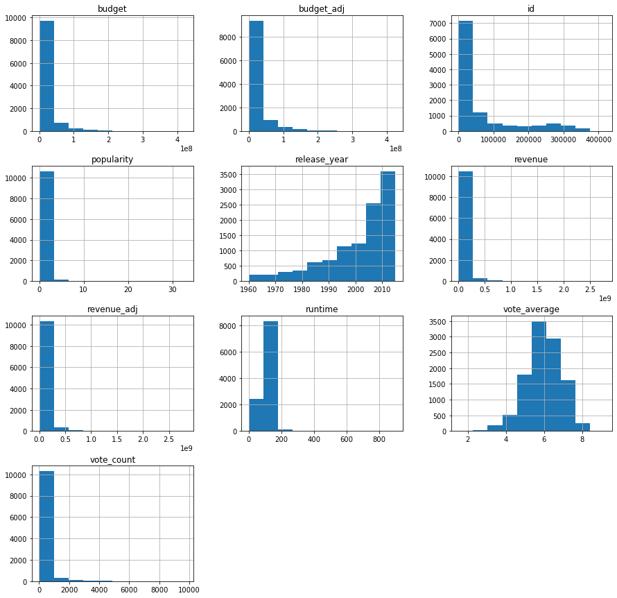

```python
df.hist(figsize=(15, 15));
```

### Data Cleaning

#### Dropping columns

Firstly, there are a lot of unnecessary columns that will not be useful for the analysis or general understanding of the data, and therefore they will be dropped. While not all of the remaining columns will be used in the analysis, they could be useful for further analysis later.

```python
drop_columns = ['id', 'imdb_id', 'homepage', 'tagline', 'keywords', 'overview']
df.drop(drop_columns, axis=1, inplace=True)
df.head()
```

|  | popularity | budget | revenue | original_title | cast | director | runtime | genres | production_companies | release_date | vote_count | vote_average | release_year | budget_adj | revenue_adj |
| --- | --- | --- | --- | --- | --- | --- | --- | --- | --- | --- | --- | --- | --- | --- | --- |
| 0 | 32.985763 | 150000000 | 1513528810 | Jurassic World | Chris Pratt\|Bryce Dallas Howard\|Irrfan Khan\|Vi... | Colin Trevorrow | 124 | Action\|Adventure\|Science Fiction\|Thriller | Universal Studios\|Amblin Entertainment\|Legenda... | 6/9/15 | 5562 | 6.5 | 2015 | 1.379999e+08 | 1.392446e+09 |
| 1 | 28.419936 | 150000000 | 378436354 | Mad Max: Fury Road | Tom Hardy\|Charlize Theron\|Hugh Keays-Byrne\|Nic... | George Miller | 120 | Action\|Adventure\|Science Fiction\|Thriller | Village Roadshow Pictures\|Kennedy Miller Produ... | 5/13/15 | 6185 | 7.1 | 2015 | 1.379999e+08 | 3.481613e+08 |
| 2 | 13.112507 | 110000000 | 295238201 | Insurgent | Shailene Woodley\|Theo James\|Kate Winslet\|Ansel... | Robert Schwentke | 119 | Adventure\|Science Fiction\|Thriller | Summit Entertainment\|Mandeville Films\|Red Wago... | 3/18/15 | 2480 | 6.3 | 2015 | 1.012000e+08 | 2.716190e+08 |
| 3 | 11.173104 | 200000000 | 2068178225 | Star Wars: The Force Awakens | Harrison Ford\|Mark Hamill\|Carrie Fisher\|Adam D... | J.J. Abrams | 136 | Action\|Adventure\|Science Fiction\|Fantasy | Lucasfilm\|Truenorth Productions\|Bad Robot | 12/15/15 | 5292 | 7.5 | 2015 | 1.839999e+08 | 1.902723e+09 |
| 4 | 9.335014 | 190000000 | 1506249360 | Furious 7 | Vin Diesel\|Paul Walker\|Jason Statham\|Michelle ... | James Wan | 137 | Action\|Crime\|Thriller | Universal Pictures\|Original Film\|Media Rights ... | 4/1/15 | 2947 | 7.3 | 2015 | 1.747999e+08 | 1.385749e+09 |

#### Missing values

As can be seen in the cell below, there are some missing values in certain columns. More specifically, there are missing values for 'cast', 'director', 'genres' and 'production_companies.' These missing values will not be filled with an average. This is because those columns contain nominal data, and therefore a mean could not be obtained and used to fill in those null values. Null values in the 'genres' column will be addressed later in the project.

```python
df.info()
```

```
<class 'pandas.core.frame.DataFrame'>
RangeIndex: 10866 entries, 0 to 10865
Data columns (total 15 columns):
 #   Column                Non-Null Count  Dtype
---  ------                --------------  -----
 0   popularity            10866 non-null  float64
 1   budget                10866 non-null  int64
 2   revenue               10866 non-null  int64
 3   original_title        10866 non-null  object
 4   cast                  10790 non-null  object
 5   director              10822 non-null  object
 6   runtime               10866 non-null  int64
 7   genres                10843 non-null  object
 8   production_companies  9836 non-null   object
 9   release_date          10866 non-null  object
 10  vote_count            10866 non-null  int64
 11  vote_average          10866 non-null  float64
 12  release_year          10866 non-null  int64
 13  budget_adj            10866 non-null  float64
 14  revenue_adj           10866 non-null  float64
dtypes: float64(4), int64(5), object(6)
memory usage: 1.2+ MB
```

#### 'Genres' variable

For the first research question, we will be using the 'genres' column. In this dataset, a film could have multiple genres. This dataset stores the genre data as a string. This can be seen from the output above as the data type for the genre is 'object'. This is because actual pointers to the strings are stored instead of strings themselves. In order to analyse the data correctly, this has to be changed. Instead of storing the multiple genres of a film as part of a string, this data will be transferred to a list containing each genre as a separate entry. This is done as data can be accessed more easily this way.

```python
new_genres = list()
for i in range(len(df['genres'])):
    genres_list = list()
    genres = df['genres'][i]
    # The line below was added to avoid the error that showed up when one of the a cells was formatted as float
    if type(genres) is not float:
        for genre in genres.split('|'):
            genres_list.append(genre)
    new_genres.append(genres_list)
# Checking the type
print(new_genres[1])
print(type(new_genres[1]))
```

```
['Action', 'Adventure', 'Science Fiction', 'Thriller']
<class 'list'>
```

```python
# Checking that the number of entries is the same.
len(new_genres) == df.shape[0]
```

```
True
```

Now the data in the data frame must be replaced with the data in the list to finalise the change.

```python
df['genres'] = new_genres
df.head()
```

|  | popularity | budget | revenue | original_title | cast | director | runtime | genres | production_companies | release_date | vote_count | vote_average | release_year | budget_adj | revenue_adj |
| --- | --- | --- | --- | --- | --- | --- | --- | --- | --- | --- | --- | --- | --- | --- | --- |
| 0 | 32.985763 | 150000000 | 1513528810 | Jurassic World | Chris Pratt\|Bryce Dallas Howard\|Irrfan Khan\|Vi... | Colin Trevorrow | 124 | [Action, Adventure, Science Fiction, Thriller] | Universal Studios\|Amblin Entertainment\|Legenda... | 6/9/15 | 5562 | 6.5 | 2015 | 1.379999e+08 | 1.392446e+09 |
| 1 | 28.419936 | 150000000 | 378436354 | Mad Max: Fury Road | Tom Hardy\|Charlize Theron\|Hugh Keays-Byrne\|Nic... | George Miller | 120 | [Action, Adventure, Science Fiction, Thriller] | Village Roadshow Pictures\|Kennedy Miller Produ... | 5/13/15 | 6185 | 7.1 | 2015 | 1.379999e+08 | 3.481613e+08 |
| 2 | 13.112507 | 110000000 | 295238201 | Insurgent | Shailene Woodley\|Theo James\|Kate Winslet\|Ansel... | Robert Schwentke | 119 | [Adventure, Science Fiction, Thriller] | Summit Entertainment\|Mandeville Films\|Red Wago... | 3/18/15 | 2480 | 6.3 | 2015 | 1.012000e+08 | 2.716190e+08 |
| 3 | 11.173104 | 200000000 | 2068178225 | Star Wars: The Force Awakens | Harrison Ford\|Mark Hamill\|Carrie Fisher\|Adam D... | J.J. Abrams | 136 | [Action, Adventure, Science Fiction, Fantasy] | Lucasfilm\|Truenorth Productions\|Bad Robot | 12/15/15 | 5292 | 7.5 | 2015 | 1.839999e+08 | 1.902723e+09 |
| 4 | 9.335014 | 190000000 | 1506249360 | Furious 7 | Vin Diesel\|Paul Walker\|Jason Statham\|Michelle ... | James Wan | 137 | [Action, Crime, Thriller] | Universal Pictures\|Original Film\|Media Rights ... | 4/1/15 | 2947 | 7.3 | 2015 | 1.747999e+08 | 1.385749e+09 |

## Exploratory Data Analysis

### Research Question 1: Does the movie genre affect its score?

Before we can start the analysis of the genres, we have to see what genres there are in the whole dataset. The code in the cell below gets all unique genres in the dataset and stores them in a list.

```python
unique_genres = list()
for genre in df['genres']:
    for g in genre:
        if g in unique_genres: continue
        unique_genres.append(g)
unique_genres
```

```
['Action',
 'Adventure',
 'Science Fiction',
 'Thriller',
 'Fantasy',
 'Crime',
 'Western',
 'Drama',
 'Family',
 'Animation',
 'Comedy',
 'Mystery',
 'Romance',
 'War',
 'History',
 'Music',
 'Horror',
 'Documentary',
 'TV Movie',
 'Foreign']
```

To see which genre has the highest average score, I have calculated the average score for each genre. This average includes any movie that has this particular genre in its list of genres, and this average was rounded to 2 decimal places. Then, these averages were stored in a dictionary for ease of access and conversion to a data frame. This process is useful as well because it will exclude all the null values, where films do not have any genre, as those films will simply not match any of the unique genres and therefore will not be included in the analysis.

```python
genre_average_score = dict()
for genre in unique_genres:
    genre_average_score[genre] = round(df[pd.DataFrame(df.genres.tolist()).isin([genre]).any(1)].vote_average.mean(),2)
genre_average_score
```

```
{'Action': 5.79,
 'Adventure': 5.94,
 'Science Fiction': 5.67,
 'Thriller': 5.75,
 'Fantasy': 5.86,
 'Crime': 6.12,
 'Western': 6.08,
 'Drama': 6.17,
 'Family': 6.0,
 'Animation': 6.4,
 'Comedy': 5.91,
 'Mystery': 5.95,
 'Romance': 6.04,
 'War': 6.3,
 'History': 6.41,
 'Music': 6.48,
 'Horror': 5.34,
 'Documentary': 6.91,
 'TV Movie': 5.79,
 'Foreign': 5.98}
```

The overall vote average was added to the dictionary to be used as a reference later. This was done in order to make comparisons more easily.

```python
genre_average_score['Overall Vote Average'] = round(df.vote_average.mean(),2)
genre_average_score
```

```
{'Action': 5.79,
 'Adventure': 5.94,
 'Science Fiction': 5.67,
 'Thriller': 5.75,
 'Fantasy': 5.86,
 'Crime': 6.12,
 'Western': 6.08,
 'Drama': 6.17,
 'Family': 6.0,
 'Animation': 6.4,
 'Comedy': 5.91,
 'Mystery': 5.95,
 'Romance': 6.04,
 'War': 6.3,
 'History': 6.41,
 'Music': 6.48,
 'Horror': 5.34,
 'Documentary': 6.91,
 'TV Movie': 5.79,
 'Foreign': 5.98,
 'Overall Vote Average': 5.97}
```

The dictionary containing all genre averages was converted from a dictionary to a data frame. This was done so that the data could be visualised more easily.

```python
genre_average_score_data = pd.DataFrame.from_dict(genre_average_score, orient='index', columns = ['genre_vote_average'])
genre_average_score_data
```

|  | genre_vote_average |
| --- | --- |
| Action | 5.79 |
| Adventure | 5.94 |
| Science Fiction | 5.67 |
| Thriller | 5.75 |
| Fantasy | 5.86 |
| Crime | 6.12 |
| Western | 6.08 |
| Drama | 6.17 |
| Family | 6.00 |
| Animation | 6.40 |
| Comedy | 5.91 |
| Mystery | 5.95 |
| Romance | 6.04 |
| War | 6.30 |
| History | 6.41 |
| Music | 6.48 |
| Horror | 5.34 |
| Documentary | 6.91 |
| TV Movie | 5.79 |
| Foreign | 5.98 |
| Overall Vote Average | 5.97 |

In order to get further understand the results, I calculated and plotted the counts for each of the genres that show how many movies there are in each genre. The same process was used to get the counts for each genre.

```python
genre_count = dict()
for genre in unique_genres:
    genre_count[genre] = df[pd.DataFrame(df.genres.tolist()).isin([genre]).any(1)].vote_average.count()
genre_count_data = pd.DataFrame.from_dict(genre_count, orient='index', columns = ['genre_count'])
genre_count_data
```

|  | genre_count |
| --- | --- |
| Action | 2385 |
| Adventure | 1471 |
| Science Fiction | 1230 |
| Thriller | 2908 |
| Fantasy | 916 |
| Crime | 1355 |
| Western | 165 |
| Drama | 4761 |
| Family | 1231 |
| Animation | 699 |
| Comedy | 3793 |
| Mystery | 810 |
| Romance | 1712 |
| War | 270 |
| History | 334 |
| Music | 408 |
| Horror | 1637 |
| Documentary | 520 |
| TV Movie | 167 |
| Foreign | 188 |

### Data Visualisation

The output below is a bar chart showing the average score for each of the genres. The red bar indicates the overall average score for all the genres.

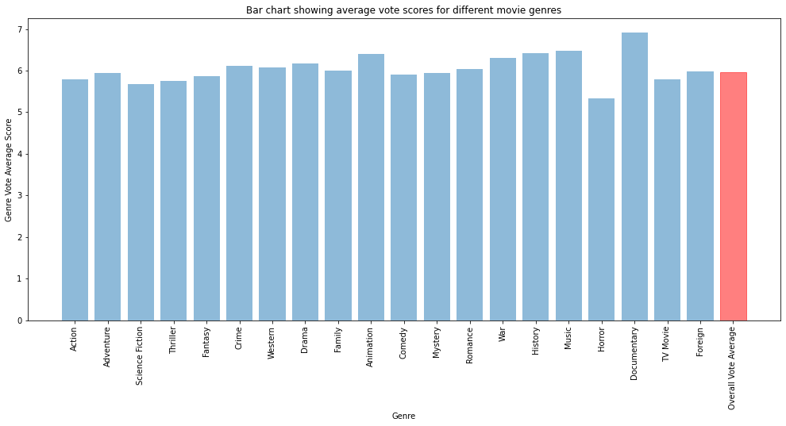

```python
plt.figure(figsize=(17,7))
genre_score_bar = plt.bar(genre_average_score_data.index, genre_average_score_data['genre_vote_average'], alpha = 0.5)
genre_score_bar[-1].set_color('r')
plt.xticks(rotation='vertical')
plt.ylabel('Genre Vote Average Score')
plt.xlabel('Genre')
plt.title('Bar chart showing average vote scores for different movie genres');
```

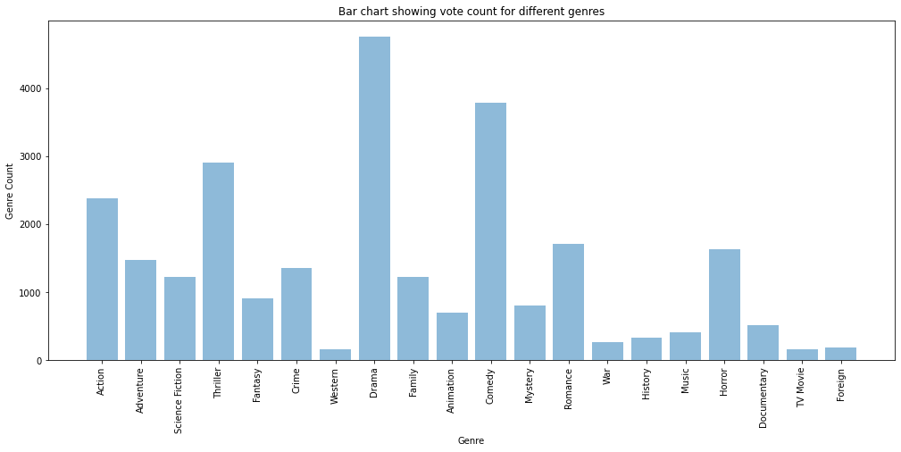

```python
plt.figure(figsize=(17,7))
genre_count_bar = plt.bar(genre_count_data.index, genre_count_data['genre_count'], alpha = 0.5)
plt.xticks(rotation='vertical')
plt.ylabel('Genre Count')
plt.xlabel('Genre')
plt.title('Bar chart showing vote count for different genres');
```

### Research Question 2: Does the movie release year affect its score?

For this research question, only the 'vote_average' and 'release_year' will be needed. A separate data frame was created to only store those columns.

```python
rq2_df = df.loc[:,['release_year', 'vote_average']]
rq2_df
```

|  | release_year | vote_average |
| --- | --- | --- |
| 0 | 2015 | 6.5 |
| 1 | 2015 | 7.1 |
| 2 | 2015 | 6.3 |
| 3 | 2015 | 7.5 |
| 4 | 2015 | 7.3 |
| ... | ... | ... |
| 10861 | 1966 | 7.4 |
| 10862 | 1966 | 5.7 |
| 10863 | 1966 | 6.5 |
| 10864 | 1966 | 5.4 |
| 10865 | 1966 | 1.5 |

10866 rows × 2 columns

To compare different years, I calculated the vote average for each year using groupby.

```python
year_average = round(rq2_df.groupby('release_year').mean(),2)
year_average.tail()
```

| release_year | vote_average |
| --- | --- |
| 2011 | 5.96 |
| 2012 | 5.80 |
| 2013 | 5.88 |
| 2014 | 5.92 |
| 2015 | 5.89 |

Once again, to further understand the results, I have also calculated the number of movies released for every year in the dataset.

```python
year_count = rq2_df.groupby('release_year').count()
year_count.tail()
```

| release_year | vote_average |
| --- | --- |
| 2011 | 540 |
| 2012 | 588 |
| 2013 | 659 |
| 2014 | 700 |
| 2015 | 629 |

### Data Visualisation

The output below is a bar chart showing the average score for each of the years in the dataset.

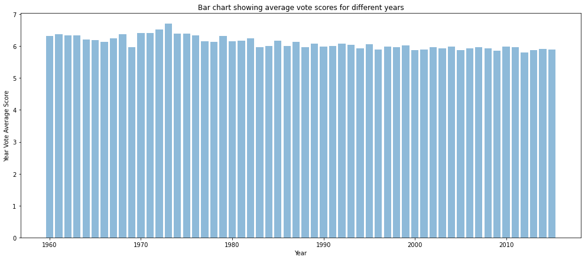

```python
plt.figure(figsize=(17,7))
plt.bar(year_average.index, year_average['vote_average'], alpha = 0.5)
plt.ylabel('Year Vote Average Score')
plt.xlabel('Year')
plt.title('Bar chart showing average vote scores for different years');
```

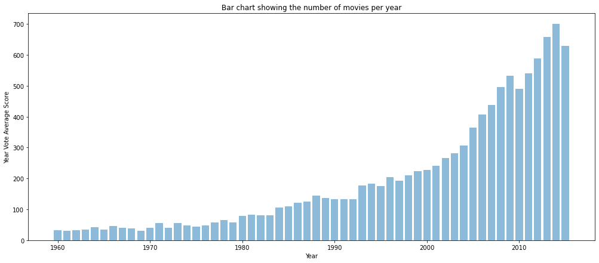

```python
plt.figure(figsize=(17,7))
plt.bar(year_count.index, year_count['vote_average'], alpha = 0.5)
plt.ylabel('Year Vote Average Score')
plt.xlabel('Year')
plt.title('Bar chart showing the number of movies per year');
```

### Research Question 3: Does the overall vote count affect the score (vote average)?

While it is crucial to examine variables such as genre or release year that could potentially influence the score of the movie, it is also important to remember that in this dataset the score of the movie is represented by the vote average which could be directly influenced by the number of people who voted.  
Similarly, to the previous research question, only 'vote_count' and 'vote_average' columns will be used. Therefore, a new data frame was created.

```python
rq3_df = df.loc[:,['vote_count', 'vote_average']]
rq3_df
```

|  | vote_count | vote_average |
| --- | --- | --- |
| 0 | 5562 | 6.5 |
| 1 | 6185 | 7.1 |
| 2 | 2480 | 6.3 |
| 3 | 5292 | 7.5 |
| 4 | 2947 | 7.3 |
| ... | ... | ... |
| 10861 | 11 | 7.4 |
| 10862 | 20 | 5.7 |
| 10863 | 11 | 6.5 |
| 10864 | 22 | 5.4 |
| 10865 | 15 | 1.5 |

10866 rows × 2 columns

```python
rq3_df.corr()
```

|  | vote_count | vote_average |
| --- | --- | --- |
| vote_count | 1.000000 | 0.253823 |
| vote_average | 0.253823 | 1.000000 |

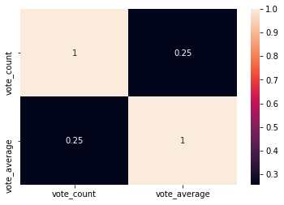

```python
sns.heatmap(rq3_df.corr(), annot=True)
plt.show()
```

For the scatterplot below the log of the vote count was used for better visualisation.

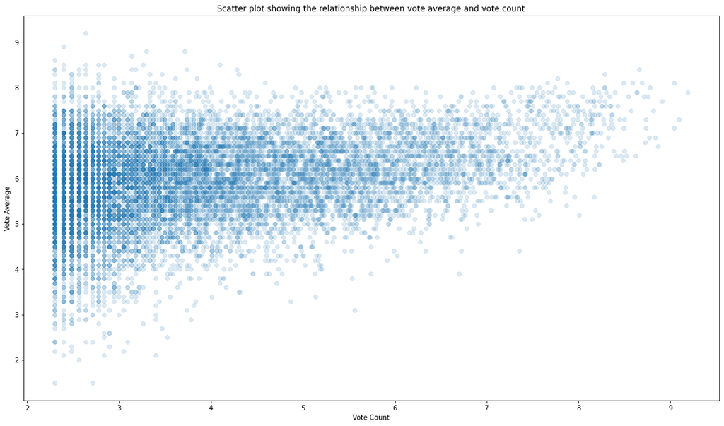

```python
rq3_reg = sns.regplot(np.log(rq3_df["vote_count"]), rq3_df["vote_average"], scatter_kws={'alpha':0.15}, fit_reg=False)
rq3_reg.figure.set_size_inches(18.5, 10.5)
rq3_reg.set(xlabel="Vote Count", ylabel='Vote Average')
rq3_reg.set_title('Scatter plot showing the relationship between vote average and vote count');
```

### Conclusion

Having analysed the data for the previous research questions, it was evident that the number of entries for each variable was needed to be considered. Consequently, it is important to analyse whether the number of votes affects the vote average itself. The original hypothesis was that higher votes would lead to lower average scores as people likely to have different opinions, and their opinions are likely to even out when more people vote. While the scatter plot shows that there could be a positive correlation between the data, the correlation matrix shows that there is only a weak positive correlation present. Therefore, this disproves the hypothesis as the vote average tends to slightly increase with the vote count. Nevertheless, while there is a weak correlation present, it does not imply causation, and further analysis will be required to determine this.  
Unlike the previous questions, the data used for this question was not categorical, and therefore a different approach for analysis was needed. Nevertheless, the data was relatively simple to collect and organise as, once again, it was already correctly formatted. There is a sufficient amount of data in this dataset for analysis for this question, and I believe that no further changes are required to improve the data for analysis.